# Practical machine learning

Anteneh

July 14, 2015

First we load the necessary packages and set the seed inorder to get reproduceable results and set our working directory.

```r
library(AppliedPredictiveModeling)
library(caret)
library(rattle)
```

```r
library(rpart.plot)
library(randomForest)
```

Our data may have NA, blank and #DIV/0!. To get rid of these we defined vector of na.strings and replace by NA.Because both data sets contain columns with all missing values, we will delete these and this help us to clean a data.

```
## [1] 19622   160
```

```
## [1]  20 160
```

After that we have checked the dimension of the new data set and then delete columns with missing values.

The first 7 columns such as user_name, raw_timestamp_part_1, raw_timestamp_part_2 cvtd_timestamp, new_window, and num_window are unnecessary for predicting our project, we delete all these variables.

Our new training data set contains 53 variables and 19622 observations where as the testing data set contains 53 variables and 20 observations.

```
## [1] 19622    53
```

```
## [1] 20 53
```

Since the data we are working is too large to performe an algorithm, the given training data set partitioned into two: Training data set into two data sets, 60% for myTraining, and subTest 40%. This can be performed with random sampling without replacement.

```
## [1] 11776    53
```

```
## [1] 7846   53
```

[output not shown]

[output cut: 69 more lines]

[output not shown]

[output cut: 69 more lines]

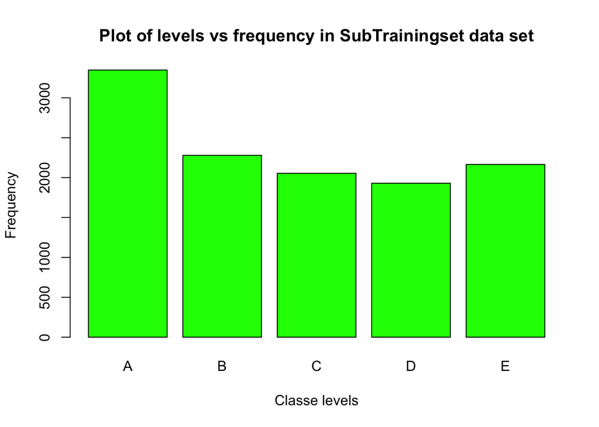

For predicition we used Decision Tree and Random Forest prediction modesl.

1. Predicting using Decision Tree and Testing the results on SubTestingset data set

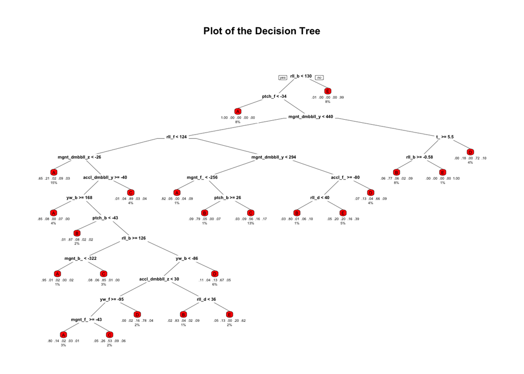

```
## Confusion Matrix and Statistics
##
##           Reference
## Prediction    A    B    C    D    E
##          A 2015  316   30  119   48
##          B   46  809   63   29   74
##          C   68  165 1120  220  190
##          D   77  121   78  817   81
##          E   26  107   77  101 1049
##
## Overall Statistics
##
##                Accuracy : 0.7405
##                  95% CI : (0.7307, 0.7502)
##     No Information Rate : 0.2845
##     P-Value [Acc > NIR] : < 2.2e-16
##
##                   Kappa : 0.6705
##  Mcnemar's Test P-Value : < 2.2e-16
##
## Statistics by Class:
##
##                      Class: A Class: B Class: C Class: D Class: E
## Sensitivity            0.9028   0.5329   0.8187   0.6353   0.7275
## Specificity            0.9086   0.9665   0.9007   0.9456   0.9514
## Pos Pred Value         0.7971   0.7924   0.6353   0.6959   0.7713
## Neg Pred Value         0.9592   0.8961   0.9592   0.9297   0.9394
## Prevalence             0.2845   0.1935   0.1744   0.1639   0.1838
## Detection Rate         0.2568   0.1031   0.1427   0.1041   0.1337
## Detection Prevalence   0.3222   0.1301   0.2247   0.1496   0.1733
## Balanced Accuracy      0.9057   0.7497   0.8597   0.7904   0.8394
```

2. Predicting using Random Forest and Test the results on SubTestingset data set.

```
## Confusion Matrix and Statistics
##
##           Reference
## Prediction    A    B    C    D    E
##          A 2231    6    0    0    0
##          B    1 1504   14    0    0
##          C    0    8 1354   22    0
##          D    0    0    0 1261    3
##          E    0    0    0    3 1439
##
## Overall Statistics
##
##                Accuracy : 0.9927
##                  95% CI : (0.9906, 0.9945)
##     No Information Rate : 0.2845
##     P-Value [Acc > NIR] : < 2.2e-16
##
##                   Kappa : 0.9908
##  Mcnemar's Test P-Value : NA
##
## Statistics by Class:
##
##                      Class: A Class: B Class: C Class: D Class: E
## Sensitivity            0.9996   0.9908   0.9898   0.9806   0.9979
## Specificity            0.9989   0.9976   0.9954   0.9995   0.9995
## Pos Pred Value         0.9973   0.9901   0.9783   0.9976   0.9979
## Neg Pred Value         0.9998   0.9978   0.9978   0.9962   0.9995
## Prevalence             0.2845   0.1935   0.1744   0.1639   0.1838
## Detection Rate         0.2843   0.1917   0.1726   0.1607   0.1834
## Detection Prevalence   0.2851   0.1936   0.1764   0.1611   0.1838
## Balanced Accuracy      0.9992   0.9942   0.9926   0.9901   0.9987
```

```
##  1  2  3  4  5  6  7  8  9 10 11 12 13 14 15 16 17 18 19 20
##  B  A  B  A  A  E  D  B  A  A  B  C  B  A  E  E  A  B  B  B
## Levels: A B C D E
```

```r
# Write files for submission
pml_write_files = function(x){
      n = length(x)
      for(i in 1:n){
            filename = paste0("problem_id_",i,".txt")
            write.table(x[i],file=filename,quote=FALSE,row.names=FALSE,col.names=FALSE)
      }
}

pml_write_files(predictedresult)
```

###### References

1. http://www.jstatsoft.org/v28/i05/paper